# Feature Effects Empirical Analysis - Preliminary Results 2024/05/29

## Mathematical Formalization

-> [Mathematical formalization of Feature Effect Errors](https://github.com/timo282/feature-effect-empirical-analysis/blob/dev/theoretical_foundation/error_terms_formalization.md)

## LRZ Server Connection

- ✅ Account and successful Log-In
- ✅ Successful data transfer via GitHub
- ✅ Running simple python scripts
- ❌ Running feature effect simulations
  - problem: how to install more recent python versions when not using Anaconda (poetry for dependency management)?

## Adaptions of Simulation Code

- 10000 points sampled for testing (1000 before)
- new noise definition: instead of absolute standard deviation, SNR (signal-to-noise rate) defining the ratio of signal standard deviation to noise standard deviation in the groundtruth; proposed values: 20,10,5
- HPO: less trials (200, fixed value indepedent of the number of HP of the model - reason: what would be a "fair" solution?)

-> implemented but not used in a simulation yet

## Correlation Analysis

### PDP Correlation Analysis

Model PDP w.r.t. Groundtruth Theoretical PDP

```python
df_melted = create_joined_melted_df(df_model_res, df_effect_res, noise_name="noise_sd_x")
df_melted
```

|  | model_id | model_x | simulation_x | n_train_x | noise_sd_x | mse_train | mse_test | mae_train | mae_test | r2_train | r2_test | feature | effect_error |
| --- | --- | --- | --- | --- | --- | --- | --- | --- | --- | --- | --- | --- | --- |
| 0 | RandomForestRegressor_20240420_1_1000_0.1 | RandomForestRegressor | 1 | 1000 | 0.1 | 1.033248 | 2.564450 | 0.797747 | 1.262403 | 0.958388 | 0.895720 | x_1 | 0.180076 |
| 1 | XGBRegressor_20240420_1_1000_0.1 | XGBRegressor | 1 | 1000 | 0.1 | 0.000746 | 0.293658 | 0.019431 | 0.406508 | 0.999970 | 0.988059 | x_1 | 0.033126 |
| 2 | DecisionTreeRegressor_20240420_1_1000_0.1 | DecisionTreeRegressor | 1 | 1000 | 0.1 | 1.592632 | 5.658174 | 0.985326 | 1.879092 | 0.935860 | 0.769917 | x_1 | 0.196085 |
| 3 | SVR_20240420_1_1000_0.1 | SVR | 1 | 1000 | 0.1 | 0.009583 | 0.018337 | 0.081111 | 0.103061 | 0.999614 | 0.999254 | x_1 | 0.015542 |
| 4 | ElasticNet_20240420_1_1000_0.1 | ElasticNet | 1 | 1000 | 0.1 | 5.716357 | 6.326010 | 1.822135 | 1.928950 | 0.769785 | 0.742760 | x_1 | 0.972314 |
| ... | ... | ... | ... | ... | ... | ... | ... | ... | ... | ... | ... | ... | ... |
| 295 | XGBRegressor_20240421_5_1000_0.5 | XGBRegressor | 5 | 1000 | 0.5 | 0.020554 | 0.600762 | 0.110879 | 0.616600 | 0.999138 | 0.976265 | x_5 | 0.014318 |
| 296 | DecisionTreeRegressor_20240421_5_1000_0.5 | DecisionTreeRegressor | 5 | 1000 | 0.5 | 1.465710 | 5.821884 | 0.937452 | 1.898664 | 0.938516 | 0.769985 | x_5 | 0.111892 |
| 297 | SVR_20240421_5_1000_0.5 | SVR | 5 | 1000 | 0.5 | 0.229592 | 0.318557 | 0.358809 | 0.454377 | 0.990369 | 0.987414 | x_5 | 0.000985 |
| 298 | ElasticNet_20240421_5_1000_0.5 | ElasticNet | 5 | 1000 | 0.5 | 6.028785 | 6.550076 | 1.905356 | 2.026085 | 0.747104 | 0.741215 | x_5 | 0.007606 |
| 299 | GAM_20240421_5_1000_0.5 | GAM | 5 | 1000 | 0.5 | 0.232448 | 0.292752 | 0.376785 | 0.431478 | 0.990249 | 0.988434 | x_5 | 0.001189 |

300 rows × 13 columns

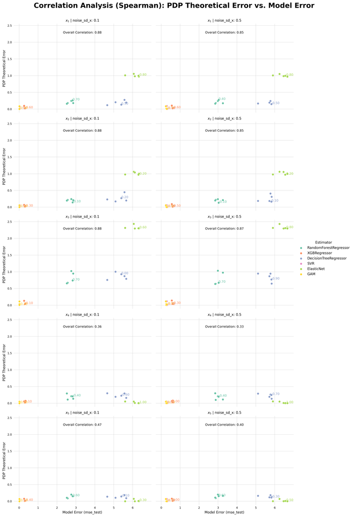

```python
g, df_corr = plot_correlation_analysis(df_melted, models, model_error_metric="mse_test", feature_effect="PDP Theoretical", correlation_metric="Spearman", overall_correlation=True, return_correlation_table=True, noise_name="noise_sd_x")
```

### ALE Correlation Analysis

Model ALE w.r.t. Groundtruth Empirical ALE

```python
df_melted = create_joined_melted_df(df_model_res, df_effect_res, noise_name="noise_sd_x")
df_melted
```

|  | model_id | model_x | simulation_x | n_train_x | noise_sd_x | mse_train | mse_test | mae_train | mae_test | r2_train | r2_test | feature | effect_error |
| --- | --- | --- | --- | --- | --- | --- | --- | --- | --- | --- | --- | --- | --- |
| 0 | RandomForestRegressor_20240413_1_1000_0.1 | RandomForestRegressor | 1 | 1000 | 0.1 | 1.033248 | 2.564450 | 0.797747 | 1.262403 | 0.958388 | 0.895720 | x_1 | 0.102209 |
| 1 | XGBRegressor_20240413_1_1000_0.1 | XGBRegressor | 1 | 1000 | 0.1 | 0.000746 | 0.293658 | 0.019431 | 0.406508 | 0.999970 | 0.988059 | x_1 | 0.088313 |
| 2 | DecisionTreeRegressor_20240413_1_1000_0.1 | DecisionTreeRegressor | 1 | 1000 | 0.1 | 1.592632 | 5.658174 | 0.985326 | 1.879092 | 0.935860 | 0.769917 | x_1 | 0.450111 |
| 3 | SVR_20240413_1_1000_0.1 | SVR | 1 | 1000 | 0.1 | 0.009583 | 0.018337 | 0.081111 | 0.103061 | 0.999614 | 0.999254 | x_1 | 0.000037 |
| 4 | ElasticNet_20240413_1_1000_0.1 | ElasticNet | 1 | 1000 | 0.1 | 5.716357 | 6.326010 | 1.822135 | 1.928950 | 0.769785 | 0.742760 | x_1 | 0.856908 |
| ... | ... | ... | ... | ... | ... | ... | ... | ... | ... | ... | ... | ... | ... |
| 295 | XGBRegressor_20240414_5_1000_0.5 | XGBRegressor | 5 | 1000 | 0.5 | 0.020554 | 0.600762 | 0.110879 | 0.616600 | 0.999138 | 0.976265 | x_5 | 0.016603 |
| 296 | DecisionTreeRegressor_20240414_5_1000_0.5 | DecisionTreeRegressor | 5 | 1000 | 0.5 | 1.465710 | 5.821884 | 0.937452 | 1.898664 | 0.938516 | 0.769985 | x_5 | 0.187126 |
| 297 | SVR_20240414_5_1000_0.5 | SVR | 5 | 1000 | 0.5 | 0.229592 | 0.318557 | 0.358809 | 0.454377 | 0.990369 | 0.987414 | x_5 | 0.000200 |
| 298 | ElasticNet_20240414_5_1000_0.5 | ElasticNet | 5 | 1000 | 0.5 | 6.028785 | 6.550076 | 1.905356 | 2.026085 | 0.747104 | 0.741215 | x_5 | 0.006440 |
| 299 | GAM_20240414_5_1000_0.5 | GAM | 5 | 1000 | 0.5 | 0.232448 | 0.292752 | 0.376785 | 0.431478 | 0.990249 | 0.988434 | x_5 | 0.000024 |

300 rows × 13 columns

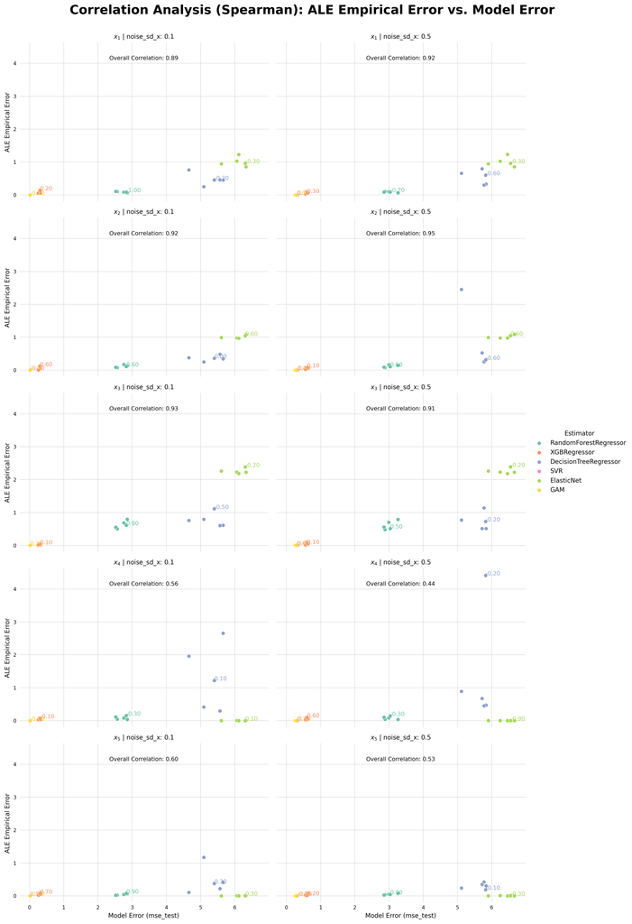

```python
g, df_corr = plot_correlation_analysis(df_melted, models, model_error_metric="mse_test", feature_effect="ALE Empirical", correlation_metric="Spearman", overall_correlation=True, return_correlation_table=True, noise_name="noise_sd_x")
```

```python
# save facet grid
g.savefig("correlation_analysis_facetgrid.png", dpi=300, bbox_inches="tight")
```

## Open Points

- analyze bias / shift of theoretical and empirical groundtruth (--> see results from last time)
- server: installation of a newer python version
- implement remaining feature effect errors (w.r.t. theoretical ALE, w.r.t. groundtruth main effect, using model main effect, w.r.t. to model main effect)
- run simulation with new set-up and config
- analyze differences feature effects of Top10 from one model class (XGBoosts) from tuning